# PURPOSe

Predicting Utilization of Resources in Psychiatry Outpatient Services

Author

Nicolas Lescano

NOTE: This project is under version control (git). All scripts and data pipeline steps are tracked for reproducibility.

[figure not shown]

**ABSTRACT**

**Objective:** To develop and evaluate machine learning models leveraging structured electronic health record (EHR) data from outpatient psychiatry to predict (1) annual provider time utilization (hours per year [HPY]) and (2) binary high-utilization tier (HUT).

**BACKGROUND AND SIGNIFICANCE**

Outpatient psychiatry is under mounting pressure. Nationwide shortages of psychiatric providers, surging demand for mental health services and increasingly complex patient needs have exposed limitations in traditional scheduling systems. Most clinics still rely on reactive or static scheduling heuristics—patients are assigned follow-ups at fixed intervals based on clinician habit, legacy templates, or insurance constraints<sup>1</sup>. These rules rarely account for individual variation in care needs, clinical complexity, or engagement patterns. As a result, patients may be under- or over-scheduled, leading to missed opportunities for timely care, provider burnout, and inefficient use of limited appointment capacity. This shortage has been formally recognized by the American Psychiatric Association, which identified psychiatry as one of the most critically understaffed medical specialties in the U.S.<sup>2</sup>

The challenge is particularly acute in psychiatry, where visit frequency and length are highly variable. Unlike procedural specialties where care is structured around predefined interventions, psychiatric care often depends on evolving therapeutic relationships, medication adjustments, psychosocial stressors and longitudinal monitoring. Mental health encounters can vary widely in length, complexity and cadence, particularly when managing severe mental illness, comorbid conditions, or social instability. Therefore, equitable access and continuity of care depend not only on capacity, but on intelligent, adaptive scheduling that reflects patient-level resource needs.

Although the mental health field has long recognized these challenges, few operational tools exist to anticipate and optimize patient scheduling. Most resource allocation efforts are manual and retrospective, adjusting schedules only after bottlenecks or missed visits occur. More proactive strategies are needed to identify high-need patients early and align them with appropriate follow-up intensity. Machine learning (ML) offers a promising framework for this task. ML methods can learn complex associations from structured EHR data, enabling prediction of outcomes like hospitalizations, appointment attendance, and medication adherence<sup>3-4</sup>. In psychiatry, ML has been applied to predict suicide risk<sup>5</sup>, treatment engagement<sup>6</sup> and therapy dropout<sup>7</sup>, but less frequently to anticipate resource utilization over time.

Most existing ML tools in behavioral health focus on short-term or single-event outcomes: whether a patient will attend their next visit, decompensate, or require hospitalization. While these predictions are clinically valuable, they do not directly support operational planning. Health systems need to understand not only who will need care, but how much, how often, and over what time horizon. Clinic directors, schedulers, and population health managers must make decisions about panel balancing, appointment spacing, and staffing based on anticipated longitudinal demand, not just isolated risks. This calls for a different class of models: those that can estimate cumulative outpatient resource needs at the patient level.

The present study, titled PURPOSe (Predicting Utilization of Resources in Psychiatry Outpatient Services), aims to fill this gap. Rather than forecasting clinical events, we sought to model longitudinal outpatient resource utilization among patients seen by psychiatric prescribers —attending psychiatrists, residents, fellows, and nurse practitioners—within a large academic health system. Our primary outcome, Hours Per Year (HPY), quantifies the total amount of provider time a patient utilizes over a 12-month period. This measure captures both the frequency and length of visits, offering a more comprehensive view of care burden than visit counts alone. HPY is directly relevant to operational concerns like RVU planning, template design, and team-based care allocation.

This work contributes a novel framework for operational forecasting in outpatient psychiatry. By modeling how much care a patient is likely to require—rather than just whether care will occur—we extend the scope of predictive analytics into clinic-level planning, triage design, and population health infrastructure. The model outputs are both interpretable and actionable, bridging the gap between algorithmic prediction and real-world resource allocation.

**METHODS**

**RESULTS**

**Utilization Load by Tier**

**DISCUSSION**

**CONCLUSION**

**FIGURE LEGENDS**

**ACKNOWLEDGMENTS**

The author used generative AI tools (ChatGPT by OpenAI) to assist with manuscript drafting and revision. All outputs were critically reviewed and revised by the author to ensure accuracy and integrity.

**COMPETING INTERESTS**

The author declares no competing interests.

**FUNDING**

This research received no specific grant from any funding agency in the public, commercial, or not-for-profit sectors.

**AUTHOR CONTRIBUTIONS**

N.L. conceived the study, conducted the data analysis, and wrote the manuscript.

**DATA AVAILABILITY**

The data used in this study were extracted from Penn Medicine’s Epic electronic health record system and contain protected health information. As such, the dataset is not publicly available. De-identified summary data and modeling code may be made available upon reasonable request to the corresponding author, subject to institutional review.

**REFERENCES**

1. Benjenk I, Chen J, Yu H. Predictors of appointment non-attendance in outpatient psychiatry. Psychiatr Serv. 2022;73(2):123–130. doi:10.1176/appi.ps.202000451
2. American Psychiatric Association. Psychiatric Workforce Shortage: Report of the APA Presidential Task Force. Washington, DC: APA; 2023. Available from:https://www.psychiatry.org/
3. Rajkomar A, Dean J, Kohane I. Machine learning in medicine. N Engl J Med. 2019;380(14):1347–1358. doi:10.1056/NEJMra1814259
4. Miotto R, Wang F, Wang S, Jiang X, Dudley JT. Deep learning for healthcare: Review, opportunities and challenges. Brief Bioinform. 2018;19(6):1236–1246. doi:10.1093/bib/bbx044
5. Walsh CG, Ribeiro JD, Franklin JC. Predicting risk of suicide attempts over time through machine learning. Clin Psychol Sci. 2018;6(3):456–472. doi:10.1177/2167702617691560
6. Greene CJ, Morland LA, Macdonald A, Frueh BC. Predictive analytics for engagement and retention in internet-based treatment for posttraumatic stress disorder. J Technol Behav Sci. 2021;6(1):29–38. doi:10.1007/s41347-020-00136-6
7. Coppersmith G, Ngo K, Leary R, Wood A, McKeown K. Assessing clinical utility of machine learning in predicting dropout from internet-based CBT for depression. J Affect Disord. 2021;282:1040–1048. doi:10.1016/j.jad.2020.12.136
8. Wright MN, Ziegler A. ranger: A fast implementation of random forests for high dimensional data in C++ and R. J Stat Softw. 2017;77(1):1–17. doi:10.18637/jss.v077.i01
9. Zulman DM, Shah NH, Verghese A. Evolutionary pressures on the electronic health record: Caring for patients versus documenting for legal and billing purposes. JAMA. 2021;326(7):613–614. doi:10.1001/jama.2021.11127

## Environment Setup

### Initiation

```r
# Install and initialize renv from scratch if needed
# (Ensures reproducible environment)

if (!requireNamespace("renv", quietly = TRUE)) {
  install.packages("renv", repos = "https://cloud.r-project.org")
}

library(renv)

Sys.setenv(RENV_CONSENT = "yes")

if (!file.exists("renv.lock")) {
  renv::init(bare = TRUE)
} else {
  renv::activate()
}
```

### Snapshot

```r
# Save current package versions to renv.lock
renv::snapshot()
```

### Package Management

```r
# Ensure all required packages are installed and loaded (within renv environment)
required_packages <- c(
  "readr", "dplyr", "tidyr", "janitor", "lubridate", "stringr", "forcats",
  "scales", "gt", "ggplot2", "tidymodels"
)

new_packages <- required_packages[!(required_packages %in% installed.packages()[,"Package"])]
if(length(new_packages)) install.packages(new_packages, repos = "https://cloud.r-project.org")

invisible(lapply(required_packages, library, character.only = TRUE))
```

## Methods

### Anonymization

```r
# Step 1: Anonymize raw visit data
# - Checks for file existence and provides informative errors
# - Outputs anonymized data and mapping files

library(readr) # for .csv reading
library(dplyr) # for data manipulation

if (!file.exists("secure/visits_raw.csv")) {
  stop("File 'secure/visits_raw.csv' not found. Please ensure the raw data is available.")
}

# Load and tag raw visit data
visits_raw <- read_csv("secure/visits_raw.csv",
                       col_types = cols(.default = col_character())) |>
  mutate(patient_key = paste(`Patient Name`, `Birth Date`, sep = "_"))


# Standardize MRNs to a canonical one per patient
full_mrn_map <- visits_raw |>
  group_by(patient_key) |>
  mutate(canonical_mrn = min(MRN)) |>
  ungroup() |>
  distinct(MRN, canonical_mrn)


# Consistency check
mrn_count <- n_distinct(full_mrn_map$canonical_mrn)
key_count <- n_distinct(visits_raw$patient_key)

message("Unique canonical MRNs: ", mrn_count)
message("Unique Name + DOB pairs: ", key_count)
if (mrn_count == key_count) {
  message("✅ Consistency check passed: canonical MRNs match unique (Name, DOB) pairs!")
} else {
  message("❌ Still inconsistent: check for remaining mismatches.")
}


# Encode MRNs
set.seed(101)
mrn_canonical_map <- full_mrn_map |>
  distinct(canonical_mrn) |>
  arrange(sample(n())) |>
  mutate(patient_id = sprintf("%05d", row_number()))

mrn_mapping <- full_mrn_map |>
  left_join(mrn_canonical_map, by = "canonical_mrn") |>
  left_join(visits_raw |> select(MRN, patient_key) |> distinct(), by = "MRN") |>
  select(MRN, canonical_mrn, patient_key, patient_id)


# Encode Providers
set.seed(202)
provider_mapping <- visits_raw |>
  distinct(`Primary Provider`) |>
  rename(provider_name = `Primary Provider`) |>
  arrange(sample(n())) |>
  mutate(provider_id = sprintf("%03d", row_number()))


# Save mapping (for future decoding if needed)
mapping <- list(
  mrn      = mrn_mapping,
  provider = provider_mapping
)


# Deidentify visits
visits_anon <- visits_raw |>
  left_join(mrn_mapping |> select(MRN, patient_id), by = "MRN") |>
  left_join(provider_mapping, by = c("Primary Provider" = "provider_name")) |>
  mutate(`Postal Code` = substr(`Postal Code`, 1, 3)) |>
  select(
    patient_id,
    provider_id,
    everything(),
    -MRN,
    -`Patient Name`,
    -`Birth Date`,
    -`Primary Provider`,
    -patient_key
  )


# Add visit_id sorted by patient/date
visits_anon <- visits_anon |>
  arrange(patient_id, `Visit Date`) |>
  mutate(visit_id = sprintf("%06d", row_number())) |>
  select(visit_id, everything())


# Save anonymized data and mappings
if (!dir.exists("data")) dir.create("data", recursive = TRUE)
if (!dir.exists("secure")) dir.create("secure", recursive = TRUE)

visits_anon |> saveRDS("data/visits_anon.rds")
mapping |> saveRDS("secure/anon.rds")
```

### Cleaning

```r
# Step 2: Clean and standardize anonymized data
# - Checks for file existence and provides informative errors
# - Outputs cleaned data for downstream analysis

library(dplyr)
library(tidyr)
library(janitor)
library(lubridate)
library(stringr)
library(forcats)

if (!file.exists("data/visits_anon.rds")) {
  stop("File 'data/visits_anon.rds' not found. Run the anonymization step first.")
}

# Read deidentified data and standardize column names
visits_clean <- readRDS("data/visits_anon.rds") |>
  clean_names()


# Manually ename columns to short, consistent names
visits_clean <- visits_clean |>
  rename(
    date              = visit_date,
    time              = appointment_time,
    length            = appointment_length_category,
    type              = visit_type,
    status            = appointment_status,
    age               = age_at_visit_years,
    sex               = legal_sex,
    race              = patient_race,
    ethnic_group      = patient_ethnic_group,
    zip3              = postal_code,
    payer             = primary_payer_financial_class,
    diagnosis         = primary_diagnosis,
    medications       = medications_ordered,
    procedures        = procedures_ordered,
    bmi               = bmi_kg_m_2,
    dbp               = bp_diastolic,
    sbp               = bp_systolic,
    provider_type     = primary_provider_type,
    copay_col         = copay_collected,
    copay_due         = copay_due,
    prepay_col        = prepayment_collected,
    prepay_due        = prepayment_due,
    los               = level_of_service,
    is_portal_active  = portal_active_at_scheduling,
    portal_engagement = my_chart_digital_engagement_metric
  )


# Convert empty strings to NA
visits_clean <- visits_clean |>
  mutate(across(where(is.character), ~ na_if(.x, "")))

# Impute NAs in diagnosis, medications, and procedures columns with "None"
visits_clean <- visits_clean |>
  mutate(across(
    c(diagnosis, medications, procedures),
    ~ replace_na(.x, "None")
  ))

# Parse dates/times, coerce types, and correct obvious typos and outliers
visits_clean <- visits_clean |>
  mutate(
    date = mdy(date),                              # calendar date
    time = round(as.numeric(hms(time)) / 3600, 2), # hours decimal

    # convert to numeric
    across(c(length, age, bmi, dbp, sbp,
             copay_col, copay_due,
             prepay_col, prepay_due,
             portal_engagement),
           as.numeric),

    # remove outliers
    bmi = if_else(bmi > 100, NA_real_, bmi),

    # fix typos
    length = case_when(
      length == 330 ~ 30,
      length == 660 ~ 60,
      TRUE          ~ length
    ),

    # zero-impute
    across(any_of(c("portal_engagement",
                    "copay_col",
                    "copay_due",
                    "prepay_col",
                    "prepay_due")),
           ~replace_na(.x, 0)),

    # consolidate copay and prepay
    pay_col = copay_col + prepay_col,
    pay_due = copay_due + prepay_due,
    pay_net = pay_due - pay_col,

    # factorize
    across(c(type, status, sex, race,
             ethnic_group, marital_status,
             religion, zip3, payer,
             provider_type, los),
           factor),

    # logical flags
    is_portal_active = as.logical(as.numeric(is_portal_active)),
    is_tele          = str_detect(type,
                                  regex("tele|video|virtual", ignore_case = TRUE))
  )

# 6. Combine SBP and DBP into one "bp" column
visits_clean <- visits_clean |>
  unite(bp, sbp, dbp, sep = "/", remove = TRUE)

# 7. Reduce cardinality and disperse levels
visits_clean <- visits_clean |>
  mutate(

    # Ethnicity binary
    is_hispanic = coalesce(ethnic_group == "Hispanic Latino", FALSE),

    # Marital status collapsing
    marital_status = factor(case_when(
      marital_status %in% c("Domestic Partner", "Partner", "Other") ~ "Other/Unknown",
      marital_status %in% c("Single", "Married", "Divorced", "Separated", "Widowed") ~ marital_status,
      TRUE ~ "Other/Unknown"
    )),

    # Collapse visit types
    type = type |>
      fct_collapse(
        `Follow up` = c(
          "ESTAB PT BRIEF", "ESTAB PT MODERATE", "ESTAB PT SHORT",
          "RETURN PATIENT VISIT", "ESTAB PT COMPREHENSIVE",
          "RPV TELEHEALTH", "COBALT TELEHEALTH RETURN",
          "TELEHEALTH VIDEO RPV", "TELEMEDICINE RETURN PATIENT"
        ),
        New = c(
          "NEW PT LONG", "NEW PT SHORT", "NEW PATIENT VISIT",
          "NPV TELEHEALTH", "COBALT TELEHEALTH NEW",
          "TELEHEALTH VIDEO NPV"
        ),
        other_level = "Other"
      ) |>
      fct_na_value_to_level("Other"),

    # Collapse race
    race = race |>
      fct_lump(n = 3, other_level = "Other/Unknown") |>
      fct_na_value_to_level("Other/Unknown"),

    # Collapse religion
    religion = factor(case_when(
      religion %in% c("No Affiliation Given", "Agnostic", "Atheist") ~ "No Religion",
      religion %in% c("Roman Catholic", "Eastern Catholic") ~ "Catholic",
      religion %in% c("Methodist", "Presbyterian", "Episcopalian", "Lutheran", "Quaker") ~ "Mainline Protestant",
      religion %in% c("Baptist", "Pentacostal", "Jehovah's Witness", "Church of God/Christian",
                      "African Methodist", "Protestant", "Fundamentalist") ~ "Evangelical/Other Protestant",
      religion %in% c("Christian", "Non-Denominational") ~ "Christian (Generic)",
      religion %in% c("Church of Jesus Christ of Latter-day Saints", "Mormon") ~ "Mormon",
      religion %in% c("Jewish", "Muslim/Moslem/Islam", "Buddhist", "Hindu") ~ religion,
      TRUE ~ "Other/Unknown"
    )),

    # Collapse ZIP3
    zip3 = zip3 |>
      fct_lump(n = 10, other_level = "Other/Unknown") |>
      fct_na_value_to_level("Other/Unknown"),

    # Collapse payer
    payer = payer |>
      fct_collapse(
        BCBS       = c("Blue Cross", "Blue Shield"),
        Medicare   = c("Medicare", "Managed Medicare"),
        Medicaid   = c("Medicaid (MA)", "Managed Medicaid"),
        Commercial = c("Commercial", "Managed Care"),
        `Self Pay` = "Self-Pay",
        other_level = "Other"
      ) |>
      fct_na_value_to_level("Other"),

    # Collapse provider type
    provider_type = provider_type |>
      fct_collapse(
        Attending         = c("Physician", "Psychiatrist"),
        `Resident/Fellow` = c("Resident", "Fellow"),
        NP                = "Nurse Practitioner"
      ) |>
      fct_na_value_to_level("Other"),

    # Collapse level of service (LOS) codes
    los = los |>
      fct_collapse(
        Psychotherapy = c("90832", "90834", "90837", "90836", "90838"),
        Psych_Eval = c("90791", "90792", "90801"),
        Med_Management = c(
          "90862", "99201", "99202", "99203", "99204", "99205",
          "99211", "99212", "99213", "99214", "99215", "99215R"
        ),
        Family_or_Group = c("90846", "90847", "90853"),
        Crisis_Therapy = c("90839", "90840"),
        Other_Psych = c(
          "90804", "90805", "90806", "90807", "90808", "90809", "90810", "90833",
          "90849", "90865", "90887", "90899", "90885", "90889"
        ),
        Substance_Tx = "H0004",
        Other_Medical = c("96102", "96372", "99358", "99443", "99080"),
        Consult = c("99241", "99242", "99243", "99244", "99245"),
        Other = "Other"
      ) |>
      fct_na_value_to_level("Other")
  ) |>

  # Drop unused factor levels
  mutate(across(where(is.factor), droplevels)) |>

  # Drop intermediate vars
  select(-c(ethnic_group, copay_col, copay_due, prepay_col, prepay_due, pay_col, pay_due))

# 8. Save the cleaned data
if (!dir.exists("data")) dir.create("data", recursive = TRUE)
visits_clean |>
  saveRDS("data/visits_clean.rds")
```

### Feature Engineering

```r
# Step 3: Feature engineering for utilization prediction
# - Loads cleaned data and applies feature engineering script
# - Outputs engineered features for modeling

# Load feature engineering script
source("scripts/engineer_utilization.R")

# Load cleaned data
visits_clean <- readRDS("data/visits_clean.rds")

# Run feature engineering
features <- engineer_utilization(
  visits_data = visits_clean,
  id_var = "patient_id",
  observed_days = 90,
  prediction_months = 12,
  static_vars = c("age", "sex", "race", "is_hispanic", "marital_status", "religion", "zip3"),
  dynamic_vars = c("payer", "pay_net", "portal_engagement", "is_portal_active", "is_tele"),
  diagnosis_var = "diagnosis",
  medications_var = "medications",
  filter_var = NULL,
  filter_levels = NULL,
  missing_threshold = 0.1,
  variance_threshold = 0.01,
  near_zero_var_threshold = 0.95,
  correlation_threshold = 0.95,
  require_complete_followup = FALSE,
  use_followup_weights = TRUE,
  output_path = "data/90d_12m.rds",
  log_file = "data/feature_engineering.log",
  timestamped_files = FALSE,
  verbose = TRUE
)
```

## Exploratory Data Analysis (EDA)

```r
# Step 4: Utilization summary and Pareto analysis

# Load engineered datasets
if (!file.exists("data/utilization_summary.rds")) {
  stop("File 'data/utilization_summary.rds' not found. Run feature engineering first.")
}

library(dplyr)
library(scales)
library(gt)
library(ggplot2)

utilization_summary <- readRDS("data/utilization_summary.rds")

# --- Utilization class summary table ---
utilization_tier_summary <- utilization_summary |>
  group_by(utilization_tier) |>
  summarise(
    n_patients   = n(),
    total_hours  = sum(n_hours),
    total_visits = sum(n_visits),
    .groups = "drop"
  ) |>
  mutate(
    pct_patients = n_patients / sum(n_patients),
    pct_hours    = total_hours / sum(total_hours),
    pct_visits   = total_visits / sum(total_visits)
  ) |>
  bind_rows(
    summarise(
      utilization_summary,
      utilization_tier     = "Total",
      n_patients     = n(),
      total_hours    = sum(n_hours),
      total_visits   = sum(n_visits),
      pct_patients   = 1,
      pct_hours      = 1,
      pct_visits     = 1
    )
  ) |>
  mutate(
    patients_n_pct = sprintf("%s (%.1f)",
                             formatC(n_patients,
                                     format = "f",
                                     big.mark = " ",
                                     digits = 0),
                             100 * pct_patients),
    visits_n_pct   = sprintf("%s (%.1f)",
                             formatC(total_visits,
                                     format = "f",
                                     big.mark = " ",
                                     digits = 0),
                             100 * pct_visits),
    hours_n_pct    = sprintf("%s (%.1f)",
                             formatC(total_hours,
                                     format = "f",
                                     big.mark = " ",
                                     digits = 0),
                             100 * pct_hours)
  )

# Format table
library(gt)
gt_table <- utilization_tier_summary |>
  select(utilization_tier, patients_n_pct, visits_n_pct, hours_n_pct) |>
  gt() |>
  cols_align(
    align = "left",
    columns = c(patients_n_pct, visits_n_pct, hours_n_pct)
  ) |>
  tab_style(
    style = cell_text(weight = "bold"),
    locations = cells_body(rows = utilization_tier == "Total")
  ) |>
  cols_label(
    utilization_tier      = "Utilization Tier",
    patients_n_pct  = "Patients, n (%)",
    visits_n_pct    = "Visits, n (%)",
    hours_n_pct     = "Hours, n (%)"
  ) |>
  tab_header(
    title = "Schedule Share by Utilization Tier"
  ) |>
  tab_options(
    table.font.size = px(12)
  )

# Display table inline
gt_table
```

Schedule Share by Utilization Tier

| Utilization Tier | Patients, n (%) | Visits, n (%) | Hours, n (%) |
| --- | --- | --- | --- |
| Top 1% | 285 (1.0) | 40 542 (13.2) | 38 046 (17.0) |
| 1–5% | 1 139 (4.0) | 65 020 (21.1) | 47 936 (21.4) |
| 5–10% | 1 354 (4.8) | 47 169 (15.3) | 28 951 (12.9) |
| 10–25% | 4 014 (14.1) | 73 482 (23.8) | 45 257 (20.2) |
| 25–50% | 7 428 (26.1) | 55 001 (17.8) | 37 207 (16.6) |
| Bottom 50% | 14 254 (50.1) | 27 078 (8.8) | 26 335 (11.8) |
| Total | 28 474 (100.0) | 308 292 (100.0) | 223 731 (100.0) |

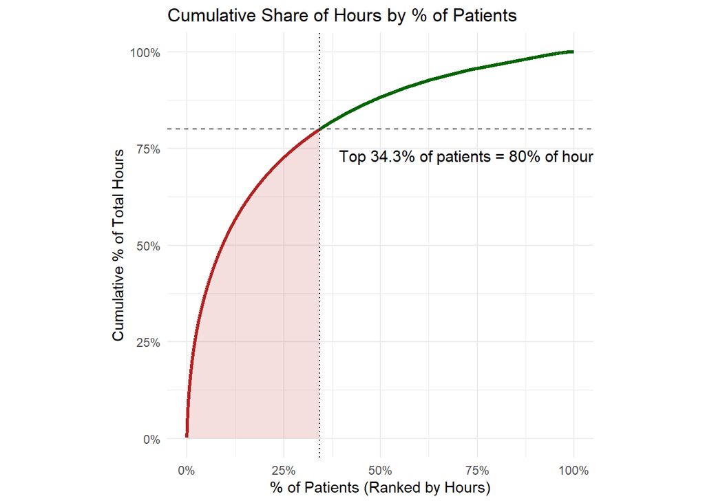

```r
# --- Pareto plot ---
n_patients <- nrow(utilization_summary)

patient_pareto <- utilization_summary |>
  arrange(desc(n_hours)) |>
  mutate(
    pct_patients = row_number() / n_patients,
    cum_hours    = cumsum(n_hours),
    pct_hours    = cum_hours / sum(n_hours),
    segment      = if_else(pct_hours < 0.80, "below_80", "above_80")
  )

cutoff <- patient_pareto |>
  filter(pct_hours >= 0.80) |>
  slice_head(n = 1)

pareto_plot <- ggplot(patient_pareto, aes(x = pct_patients, y = pct_hours)) +
  geom_area(
    data = subset(patient_pareto, segment == "below_80"),
    fill = "firebrick", alpha = 0.15
  ) +
  geom_line(
    data = subset(patient_pareto, segment == "below_80"),
    color = "firebrick", size = 1.2
  ) +
  geom_line(
    data = subset(patient_pareto, segment == "above_80"),
    color = "darkgreen", size = 1.2
  ) +
  geom_hline(yintercept = 0.80, linetype = "dashed", color = "gray30") +
  geom_vline(xintercept = cutoff$pct_patients, linetype = "dotted", color = "black") +
  annotate(
    "text",
    x = cutoff$pct_patients + 0.05,
    y = 0.7,
    label = sprintf("Top %.1f%% of patients = 80%% of hours", 100 * cutoff$pct_patients),
    hjust = 0, vjust = -0.5, size = 4, color = "black"
  ) +
  scale_x_continuous(labels = percent_format(accuracy = 1)) +
  scale_y_continuous(labels = percent_format(accuracy = 1)) +
  labs(
    title = "Cumulative Share of Hours by % of Patients",
    x = "% of Patients (Ranked by Hours)",
    y = "Cumulative % of Total Hours"
  ) +
  theme_minimal() +
  coord_fixed()

# Display plot inline
print(pareto_plot)
```